# Assignment3_VIS

Megan Willis-Jackson

9/29/2020

# Load Libraries

```r
library(sf)
library(tidyverse)
library(ggthemes)
library(CycleInfraLnd)
library(gridExtra)
library(ggspatial)
library(units)
library(nngeo)
library(grid)
library(ggimage)
```

I don’t end up using all of the below datasets in my subsequent analysis, but am leaving them here in case I want to use them later. I have commented out the ones I don’t use to speed up the knitting process.

```r
london<- st_read("C:/Users/mwill/OneDrive - Harvard University/2020 - Fall/Spatial Analysis/Git/mwillisjackson-vis/Data/London-wards-2018/London-wards-2018_ESRI", quiet = T)

openspace<- st_read("https://data.london.gov.uk/download/designated_open_space/03cb12ea-d6ef-46f2-9d8e-b95380af1a24/Designated_Open_Space.gpkg", quiet = T)

#housingzones<- st_read("https://data.london.gov.uk/download/housing_zones/3239c52f-0c34-41a3-bf18-1408ee53010f/Housing_Zones.gpkg", quiet = T)

#bus_lowems<- st_read("https://data.london.gov.uk/download/low_emission_bus_zones/9eacb8ee-345b-49e6-97d9-b3677c62652c/Low_Emission_Bus_Zones_line.gpkg", quiet = T)

#I'm commenting this line out because it takes forever to load (huge dataset), but if you're running
#it for the first time you should remove the #
osm<- st_read("http://download.geofabrik.de/europe/great-britain/england/greater-london-latest.osm.pbf", quiet = T)

#pop<- read.csv("C:/Users/mwill/OneDrive - Harvard University/2020 - Fall/Spatial Analysis/Git/mwillisjackson-vis/Data/population-estimates-single-year-age.csv")

#london<- merge(london, pop, by.x = "LAGSSCODE", by.y = "Code")
#london<- london[,1:8]
#london_bor<- unique(london$DISTRICT)
#london_bor

#postbox<- osm[which(grepl("post_box",osm$other_tags) == T),]

pub<- osm[which(grepl("public_transport", osm$other_tags) == F),]
pub<- pub[which(grepl("pub", pub$other_tags) == T),]

banksy<- osm[which(grepl("Banksy", osm$other_tags) == T),]

speedcam<- osm[which(osm$highway == "speed_camera"),]

noise_night<- st_read("C:/Users/mwill/OneDrive - Harvard University/2020 - Fall/Spatial Analysis/Git/mwillisjackson-vis/Data/Road_Lnight_London", quiet = T)

#bike<- get_cid_lines("cycle_lane_track")
#traf_calm<- get_cid_points("traffic_calming")
```

# Selected Variables

I will work with 5 variables:

1. London neighborhoods (polygons)
2. London designated openspace (polygons)
3. London speedcams (points)
4. London pubs (points)
5. Banksy murals in London (points)

```r
uk_proj<- "+proj=tmerc +lat_0=49 +lon_0=-2 +k=0.9996012717 +x_0=400000 +y_0=-100000 +ellps=airy +units=m +no_defs"

london_transform<- london %>%
  st_transform(crs = uk_proj)

openspace_transform<- openspace %>%
  st_transform(crs = uk_proj)

#bike_transform<- bike %>%
 # st_transform(crs = uk_proj)

#housing_transform<- housingzones %>%
 # st_transform(crs = uk_proj)

noise_night_loud<- noise_night[which(noise_night$NoiseClass == ">=70.0"),] %>%
  st_transform(crs = uk_proj)

noise_night_transform<- noise_night %>%
  st_transform(crs = uk_proj)

speedcam_transform<- speedcam %>%
  st_transform(crs = uk_proj)

pub_transform<- pub %>%
  st_transform(crs = uk_proj)

banksy_transform<- banksy %>%
  st_transform(crs = uk_proj)
```

```r
#the below code links an image of the Banksy mural with the dataframe so that
#the images can be called on a ggplot later on.
banksy_transform$image <- c("https://uploads3.wikiart.org/images/banksy.jpg",
                            "https://uploads3.wikiart.org/images/banksy.jpg",
                            "https://i.pinimg.com/originals/53/3b/dd/533bddad83f1dcdd48d22b2109a8d16c.jpg",
                            "https://static.dezeen.com/uploads/2012/05/Dezeen_Banksy-in-Hackney-4.jpg",
                            "https://i.dailymail.co.uk/i/pix/2011/08/06/article-0-0D519F4100000578-426_634x478.jpg",
                            "https://cdn.shopify.com/s/files/1/2105/3701/products/Banksy_If_Graffiti_Was_Illegal_Wall_Sticker_b_720x.jpg?v=1571713884",
                            "https://guyhepner.com/wp-content/uploads/2015/11/Screen-Shot-2015-11-25-at-1.29.07-PM-570x378.png",
                            "https://upload.wikimedia.org/wikipedia/en/8/8d/Crazy_Beat_Blur.jpg",
                            "https://www.thesun.co.uk/wp-content/uploads/2016/04/1683341.main_image.jpg?strip=all",
                            "https://www.thesun.co.uk/wp-content/uploads/2016/04/1683339.main_image.jpg?strip=all",
                            "https://www.thesun.co.uk/wp-content/uploads/2016/04/1683342.main_image.jpg?strip=all")

banksy_transform$x <- substr(banksy_transform$geometry, 3, 18)
banksy_transform$x <- gsub(",","",banksy_transform$x)
banksy_transform$x <- as.numeric(banksy_transform$x)

banksy_transform$y <- substr(banksy_transform$geometry, 20, 36)
banksy_transform$y <- gsub(")","",banksy_transform$y)
banksy_transform$y <- as.numeric(banksy_transform$y)
```

# Maps

## Speedcams within 0.5 km of a London Pub

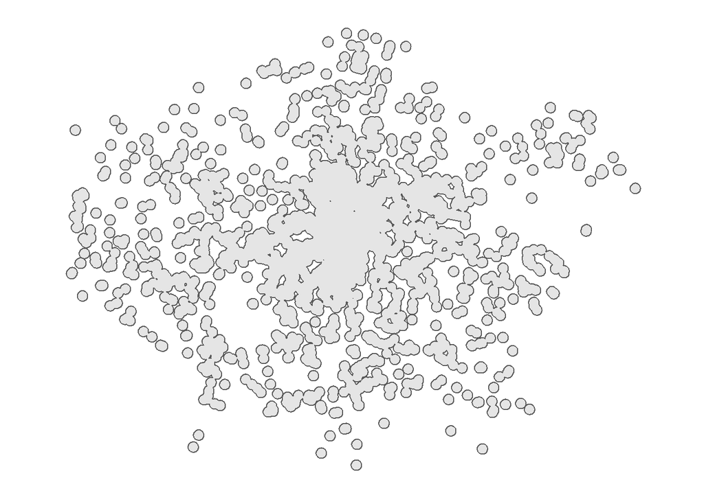

```r
pub_buffer<- st_buffer(pub_transform, dist = 500) %>%
  st_union()

ggplot(pub_buffer) +
  geom_sf() +
  theme_map()
```

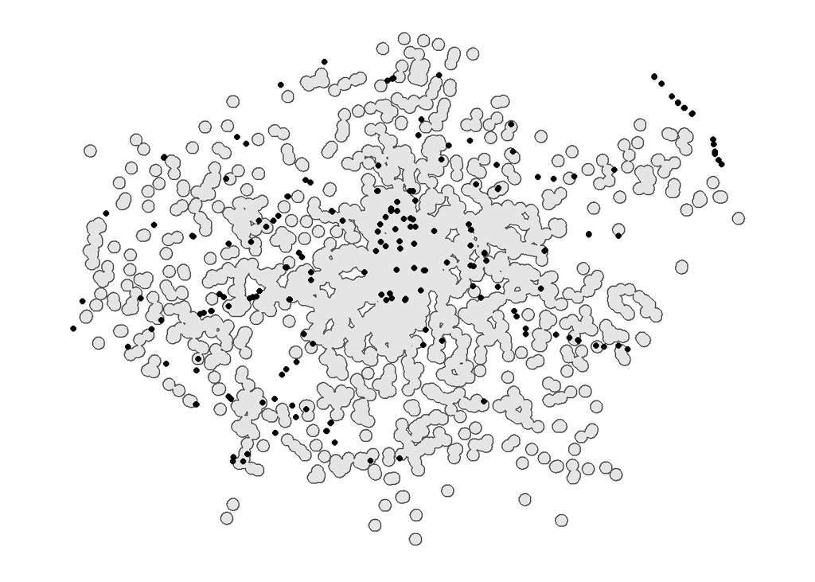

```r
pub_cams<- speedcam_transform[pub_buffer,]

ggplot(pub_buffer) +
  geom_sf() +
  geom_sf(data = pub_cams, size = .01) +
  geom_sf(data = speedcam_transform) +
  theme_map()
```

```r
speedcam2 <- speedcam_transform %>%
  st_join(pub_cams) %>%
  mutate(by_pub = !is.na(highway.y))


n_pub_cams <- sum(speedcam2$by_pub)
n_pub_cams
```

```
hide [1] 101
```

```r
n_cams<- length(speedcam2$by_pub)
pct_pub_cams<- n_pub_cams / n_cams
pct_pub_cams
```

```
hide [1] 0.510101
```

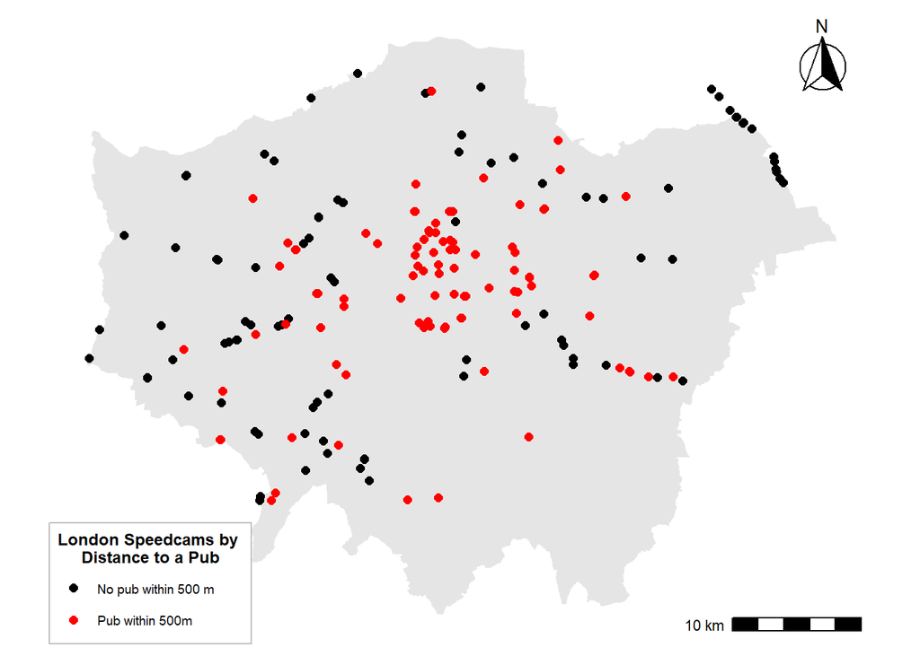

```r
ggplot(london_transform) +
  geom_sf(color = NA) +
  geom_sf(data = speedcam2,
          aes(color = by_pub), size = 2) +
  scale_color_manual(values = c("black","red"),
                     name = "London Speedcams by \nDistance to a Pub",
                     labels = c("No pub within 500 m",
                                "Pub within 500m")) +
  annotation_scale(location = "br") +
  annotation_north_arrow(location = "tr",
                         style = north_arrow_fancy_orienteering()) +
  theme_map() +
  theme(legend.background = element_rect(fill = alpha("white",.5), color = "grey"),
        legend.title = element_text(face = "bold"),
        legend.title.align = .5)
```

## Number of Pubs by London Neighborhood

London has a lot of pubs. The number of pubs present per neighborhood increases the closer the neighborhood is to the center of London, unsurprisingly given the increased population density than in the outer ring. This isn’t visualized in the maps below, but the neighborhood with the highest pub-count by population is the City and County of London (which is tiny and right in the center), which has 1.2 pubs per 100 people.

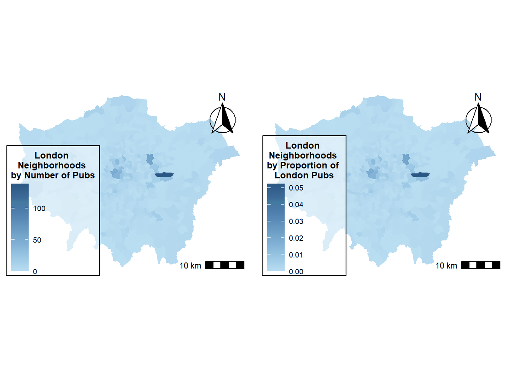

```r
london_transform<- london_transform %>%
  mutate(num_pubs = lengths(st_covers(london_transform, pub_transform)))

#proportion of pubs
london_transform<- london_transform %>%
  mutate(prop_pubs = num_pubs / length(pub_transform$osm_id))

num_pubs_map<- ggplot(london_transform) +
  geom_sf(color = NA,
          aes(fill = num_pubs)) +
  scale_fill_continuous_tableau(name = "London \nNeighborhoods \nby Number of Pubs") +
  annotation_scale(location = "br") +
  annotation_north_arrow(location = "tr",
                         style = north_arrow_fancy_orienteering()) +
  theme_map() +
  theme(legend.background = element_rect(fill = alpha("white", .5),
                                         color = "black"),
        legend.title = element_text(face = "bold"),
        legend.title.align = .5)

prop_pubs_map<- ggplot(london_transform) +
  geom_sf(color = NA,
          aes(fill = prop_pubs)) +
  scale_fill_continuous_tableau(name = "London \nNeighborhoods \nby Proportion of \nLondon Pubs") +
  annotation_scale(location = "br") +
  annotation_north_arrow(location = "tr",
                         style = north_arrow_fancy_orienteering()) +
  theme_map() +
  theme(legend.background = element_rect(fill = alpha("white", .5),
                                         color = "black"),
        legend.title = element_text(face = "bold"),
        legend.title.align = .5)

grid.arrange(num_pubs_map, prop_pubs_map, nrow = 1, ncol = 2)
```

## Density of Pubs by London Neighborhoods

As shown above, not only do the neighborhoods closest to the center of London have the highest number of pubs, they also have the highest density, given that they cover a smaller area.

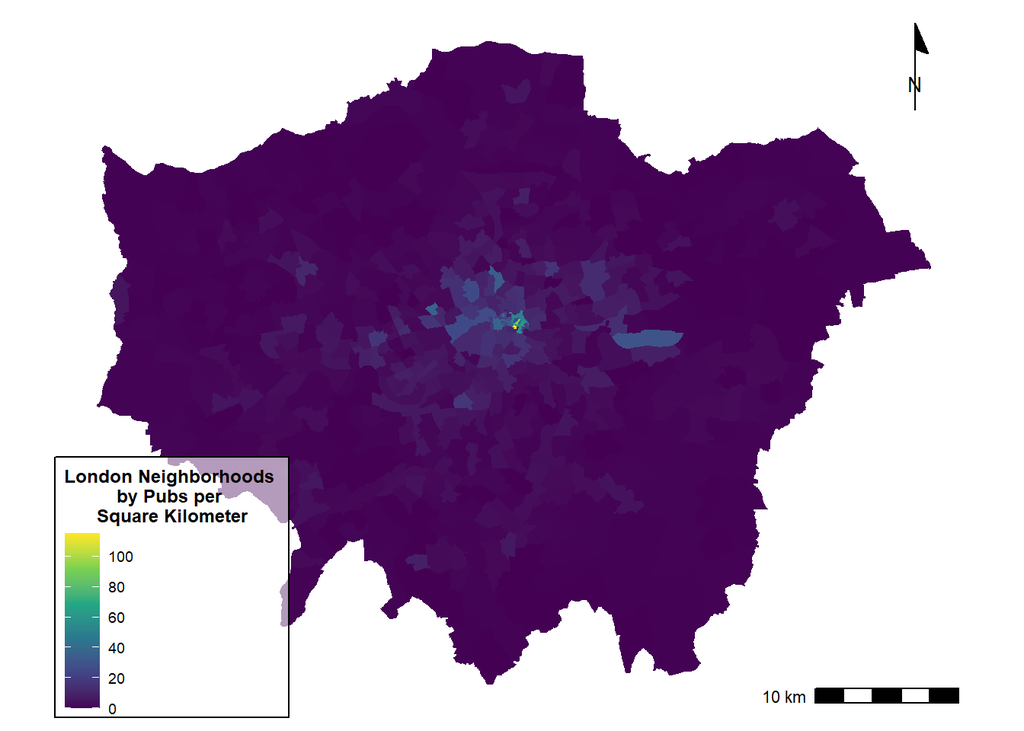

```r
london_transform<- london_transform %>%
  mutate(area = set_units(st_area(london_transform), km^2)) %>%
  mutate(pub_dens = as.numeric(num_pubs / area))

ggplot(london_transform) +
  geom_sf(color = NA,
          aes(fill = pub_dens)) +
  scale_fill_viridis_c(name = "London Neighborhoods \nby Pubs per \nSquare Kilometer",
                       breaks = seq(0, 120, by = 20)) +
  annotation_north_arrow(location = "tr",
                         style = north_arrow_minimal()) +
  annotation_scale(location = "br") +
  theme_map() +
  theme(legend.background = element_rect(fill = alpha("white",.6), color = "black"),
        legend.title = element_text(face = "bold"),
        legend.title.align = .5)
```

## Overlap of Openspace and London Neighborhoods

```r
london_transform<- london_transform %>%
  mutate(num_open = lengths(st_overlaps(london_transform, openspace_transform))) %>%
  mutate(has_open = num_open > 0)

n_open_nhoods<- sum(london_transform$has_open)
n_open_nhoods
```

```
hide [1] 574
```

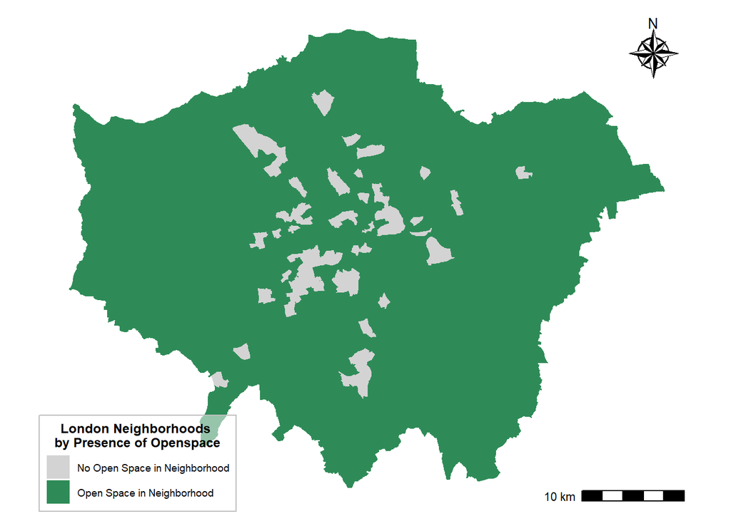

```r
ggplot(london_transform) +
  geom_sf(aes(fill = has_open), color = NA) +
  scale_fill_manual(values = c("lightgrey","seagreen4"),
                    name = "London Neighborhoods \nby Presence of Openspace",
                    labels = c("No Open Space in Neighborhood",
                               "Open Space in Neighborhood")) +
  annotation_scale(location = "br") +
  annotation_north_arrow(location = "tr",
                         style = north_arrow_nautical()) +
  theme_map() +
  theme(legend.background = element_rect(fill = alpha("white", .5),
                                         color = "grey"),
        legend.title = element_text(face = "bold"),
        legend.title.align = .5)
```

## Distance from Pub to Nearest Openspace

Given there is so much open space in London as well as so many pubs, it’s not all that surprising that the vast majority of pubs are within about 300 m of designated open space. To add a little more specificity though, the average distance from a pub to the nearest open space is about 151 m.

```r
pub_transform<- pub_transform %>%
  mutate(open_dist = st_nn(pub_transform, openspace_transform,
                          returnDist = T)$dist) %>%
  mutate(open_dist = as.numeric(open_dist))
```

```
hide
```

```r
avg_open_dist<- mean(pub_transform$open_dist)
avg_open_dist
```

```
hide [1] 151.1506
```

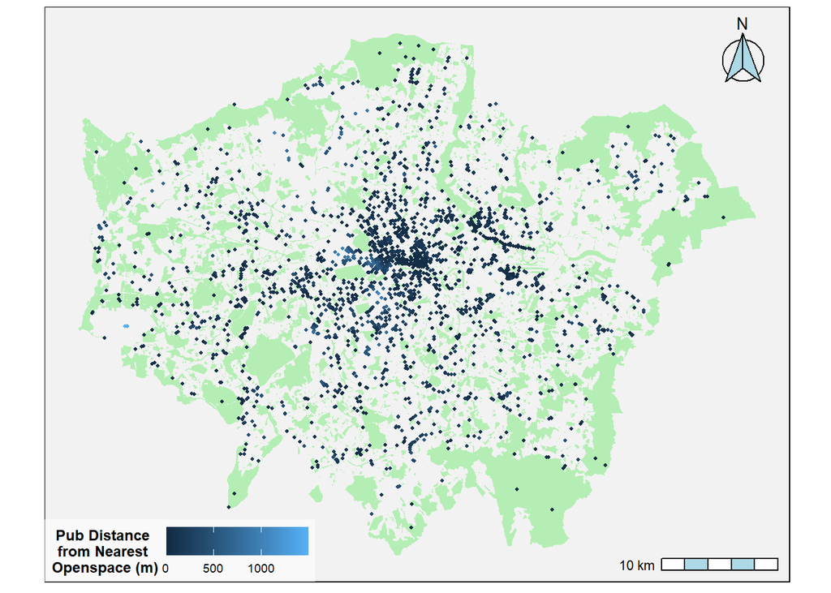

```r
ggplot(openspace_transform) +
  geom_sf(fill = "darkseagreen2", color = NA) +
  geom_sf(data = pub_transform, size = .8,
          aes(color = open_dist)) +
  scale_color_gradient(name = "Pub Distance \nfrom Nearest \nOpenspace (m)") +
  theme_map() +
  annotation_scale(bar_cols = c("white","lightblue"),
                   location = "br") +
  annotation_north_arrow(location = "tr",
                         style = north_arrow_fancy_orienteering(fill = "lightblue", text_col = "black")) +
  theme(panel.background = element_rect(fill = "grey95"),
        legend.background = element_rect(fill = alpha("white",.5)),
        legend.direction = "horizontal",
        legend.title = element_text(face = "bold"),
        legend.title.align = .5)
```

## Distance between Banksy Murals and Nearest Pub

If you were to happen upon a Banksy mural, how far on average would you have to go to get to the nearest pub at which you can contemplate the themes you’ve just witnessed? Not very far, as it turns out. Of the 11 murals in the dataset, they are an average of 130.6 meters away from the nearest London pub.

```r
banksy_transform<- banksy_transform %>%
  mutate(pub_dist = st_nn(banksy_transform, pub_transform,
                          returnDist = T)$dist) %>%
  mutate(pub_dist = as.numeric(pub_dist))
```

```
hide
```

```r
avg_pub_dist<- mean(banksy_transform$pub_dist)

avg_pub_dist
```

```
hide [1] 130.6038
```

[figure not shown]

```r
right_side<- st_bbox(banksy_transform)$xmax+1000
left_side<- st_bbox(banksy_transform)$xmin-1000
top_side<- st_bbox(banksy_transform)$ymax+1000
bottom_side<- st_bbox(banksy_transform)$ymin-1000

banksy_map<- ggplot(london_transform) +
  geom_sf(aes(fill = DISTRICT), color = NA, alpha = .4, show.legend = F) +
  geom_sf(data = banksy_transform, aes(color = pub_dist)) +
  geom_sf_label(aes(label = ifelse(NAME == "Regent's Park" & DISTRICT == "Camden", "Camden\n",
                            ifelse(NAME == "Holloway", "Islington",
                            ifelse(NAME == "Shadwell", "Tower \nHamlets",
                            ifelse(NAME == "Bishop's", "Lambeth",
                            ifelse(NAME == "Bread Street", "City of \nLondon",
                            ifelse(NAME == "Hackney Central", "Hackney",
                            ifelse(NAME == "St. James's", "\n\n\n\nCity of \nWestminster",
                            ifelse(NAME == "Stratford and New Town", "Newham", ""))))))))),
                size = 3, fill = NA, label.size = NA) +
  geom_point(data = banksy_transform, aes(x = x, y = y, color = pub_dist), size = 25, shape = 15, alpha = .7) +
  geom_image(data = banksy_transform, aes(x = x, y = y, image=image), size = .1) +
  coord_sf(xlim = c(left_side, right_side),
           ylim = c(bottom_side, top_side), expand = F) +
  scale_color_viridis_c(name = "Distance to \nNearest Pub \n(meters)") +
  scale_fill_grey() +
  theme_map() +
  theme(legend.justification = c(-1.65, -7.4),
        legend.background = element_rect(fill = alpha("white",.4),
        color = "grey"),
        legend.direction = "horizontal",
        legend.title.align = .5,
        legend.title = element_text(face = "bold")) +
  labs(title = "Distance from a Banksy Mural to the Nearest Pub for Contemplation") +
  annotation_scale(location = "bl") +
  annotation_north_arrow(location = "br",
                         style = north_arrow_fancy_orienteering())

grid.arrange(banksy_map +
               labs(caption = "*OSM provided the location of two murals that \ndid not have an associated mural title, so a classic Banksy mural is portrayed instead."))
```